# Data Visualization

Nolan Cardozo

1 February 2017

## The ODI BATTING DATA

The `ODI Batting` dataset contains facts about different International cricketers who have batted in the One day International format of the game of cricket over the years since the inception of the sport Cricket.

Some of the variables in the `ODI Batting` dataset are: *(Also classifying them into(Dimensions, Metrics, Dates, Text and Geo))*

- **Country** - The names of countries which have played or are still playing cricket over the years**(Dimension)**
- **Player** - The name of various players who have batted in international cricket since the inception of the sport**(Dimension)**
- **Runs** - The Runs scored by players on a particular match date**(Metric)**
- **Score Rate** - The rate at which the batsman has scored runs in a particular match. **(Metric)**
- **MatchDate** - The Date on which a particular cricket match was played **(Date)**
- **Ground** - The name of Ground at which the match was played **(Dimension)**
- **Versus** - The opponent country against whom the match was played. **(Dimension)**
- **Month,Year,Day,Weekday** - These all are derived attributes from the Match Date variable.**(Date)**

## Reading the dataset into R.

```r
odi_players <- read.csv("C:/Users/Admin/Desktop/data visulisation/odi-batting-analysis.csv")
```

## Inspecting the first and last 6 rows of the data for better undertanding of contents.

```r
head(odi_players)
```

```
##       Country           Player Runs ScoreRate  MatchDate                Ground      Versus month
## 1 Afghanistan Mohammad Shahzad  118     97.52 16-02-2010    Sharjah CA Stadium      Canada     2
## 2 Afghanistan Mohammad Shahzad  110     99.09 01-09-2009            VRA Ground Netherlands     9
## 3 Afghanistan Mohammad Shahzad  100    138.88 16-08-2010 Cambusdoon New Ground    Scotland     8
## 4 Afghanistan Mohammad Shahzad   82     75.92 10-07-2010           Hazelaarweg Netherlands     7
## 5 Afghanistan Mohammad Shahzad   57    100.00 01-07-2010   Sportpark Westvliet      Canada     7
## 6 Afghanistan Mohammad Shahzad   55     87.30 07-07-2010   Sportpark Westvliet Netherlands     7
##   year day weekday
## 1 2010  16       3
## 2 2009   1       3
## 3 2010  16       2
## 4 2010  10       7
## 5 2010   1       5
## 6 2010   7       4
```

```r
tail(odi_players)
```

```
##        Country              Player Runs ScoreRate  MatchDate                 Ground      Versus
## 55921 Zimbabwe Waddington Mwayenga    1        50 29-05-2004     Harare Sports Club   Australia
## 55922 Zimbabwe Waddington Mwayenga    0         0 27-05-2004     Harare Sports Club   Australia
## 55923 Zimbabwe  Tafadzwa Kamungozi    0         0 10-10-2006   Sardar Patel Stadium   Sri Lanka
## 55924 Zimbabwe  Tafadzwa Kamungozi    0         0 08-10-2006   Sardar Patel Stadium West Indies
## 55925 Zimbabwe  Tafadzwa Kamungozi    0         0 13-10-2006 Sawai Mansingh Stadium  Bangladesh
## 55926 Zimbabwe       Njabulo Ncube    0         0 25-10-2011     Queens Sports Club New Zealand
##       month year day weekday
## 55921     5 2004  29       7
## 55922     5 2004  27       5
## 55923    10 2006  10       3
## 55924    10 2006   8       1
## 55925    10 2006  13       6
## 55926    10 2011  25       3
```

## Inspecting the structure of the data.

```r
str(odi_players)
```

```
## 'data.frame':    55926 obs. of  11 variables:
##  $ Country  : Factor w/ 22 levels "Afghanistan",..: 1 1 1 1 1 1 1 1 1 1 ...
##  $ Player   : Factor w/ 1936 levels "Aamer Hanif",..: 1173 1173 1173 1173 1173 1173 1173 1173 1173 1173 ...
##  $ Runs     : int  118 110 100 82 57 55 37 34 20 16 ...
##  $ ScoreRate: num  97.5 99.1 138.9 75.9 100 ...
##  $ MatchDate: Factor w/ 2757 levels "01-01-1975","01-01-1987",..: 1392 57 1429 852 50 573 777 760 397 2675 ...
##  $ Ground   : Factor w/ 178 levels "AC-VDCA Stadium",..: 138 170 25 53 150 150 50 53 170 170 ...
##  $ Versus   : Factor w/ 25 levels "ACA Africa XI",..: 7 16 19 16 7 16 14 19 14 16 ...
##  $ month    : int  2 9 8 7 7 7 10 7 7 8 ...
##  $ year     : int  2010 2009 2010 2010 2010 2010 2010 2010 2010 2009 ...
##  $ day      : int  16 1 16 10 1 7 9 9 5 30 ...
##  $ weekday  : int  3 3 2 7 5 4 7 6 2 1 ...
```

## The number of rows and columns in the dataset.

```r
dim(odi_players)
```

```
## [1] 55926    11
```

## Running basic summary statistics on the data.

```r
summary(odi_players,maxsum = 15)
```

```
##          Country                        Player           Runs          ScoreRate
##  India       :6634   Sachin R Tendulkar    :  442   Min.   :  0.00   Min.   :  0.00
##  Pakistan    :6603   Sanath T Jayasuriya   :  433   1st Qu.:  4.00   1st Qu.: 37.50
##  Australia   :6325   Ricky T Ponting       :  360   Median : 13.00   Median : 62.66
##  Sri Lanka   :5604   Inzamam-ul-Haq        :  351   Mean   : 22.24   Mean   : 65.31
##  West Indies :5557   D P Mahela Jayawardene:  330   3rd Qu.: 32.00   3rd Qu.: 87.50
##  New Zealand :5437   Rahul Dravid          :  318   Max.   :200.00   Max.   :600.00
##  England     :5101   Mohammad Azharuddin   :  308   NA's   :26       NA's   :26
##  South Africa:3864   Jacques H Kallis      :  303
##  Zimbabwe    :3814   Shahid Afridi         :  303
##  Bangladesh  :2459   Sourav C Ganguly      :  300
##  Kenya       :1379   Pinnaduwage A de Silva:  296
##  Canada      : 685   Brian C Lara          :  289
##  Ireland     : 624   Stephen R Waugh       :  288
##  Netherlands : 604   Kumar C Sangakkara    :  282
##  (Other)     :1236   (Other)               :51323
##       MatchDate                              Ground               Versus         month
##  04-02-2007:  108   Sharjah CA Stadium          : 3581   Australia   :7216   Min.   : 1.00
##  11-06-1983:   82   Sydney Cricket Ground       : 2462   India       :6836   1st Qu.: 2.00
##  03-07-2010:   80   Melbourne Cricket Ground    : 2308   Pakistan    :6667   Median : 5.00
##  02-02-2007:   78   R. Premadasa Stadium        : 1797   West Indies :5816   Mean   : 5.79
##  16-06-1979:   76   Harare Sports Club          : 1784   Sri Lanka   :5502   3rd Qu.:10.00
##  09-06-1983:   75   Adelaide Oval               : 1262   New Zealand :5256   Max.   :12.00
##  14-06-1975:   72   W.A.C.A. Ground             : 1222   England     :5026
##  10-07-2010:   71   Brisbane Cricket Ground     : 1184   South Africa:4284
##  18-06-1983:   69   Gymkhana Club Ground        : 1123   Zimbabwe    :3259
##  13-06-1983:   67   Eden Park                   : 1100   Bangladesh  :1985
##  31-01-2007:   67   Queen's Park Oval           : 1015   Kenya       :1118
##  11-06-1975:   66   Gaddafi Stadium             : 1013   Ireland     : 614
##  20-06-1983:   65   Bangabandhu National Stadium: 1005   Canada      : 569
##  24-06-2008:   63   Sinhalese Sports Club Ground:  965   Netherlands : 557
##  (Other)   :54887   (Other)                     :34105   (Other)     :1221
##       year           day           weekday
##  Min.   :1971   Min.   : 1.00   Min.   :1.000
##  1st Qu.:1993   1st Qu.: 8.00   1st Qu.:2.000
##  Median :2000   Median :16.00   Median :4.000
##  Mean   :1999   Mean   :15.66   Mean   :4.021
##  3rd Qu.:2006   3rd Qu.:23.00   3rd Qu.:6.000
##  Max.   :2011   Max.   :31.00   Max.   :7.000
##
##
##
##
##
##
##
##
##
```

## 1. Create a bar chart which plots total runs by month, by day of week and by day of the month.

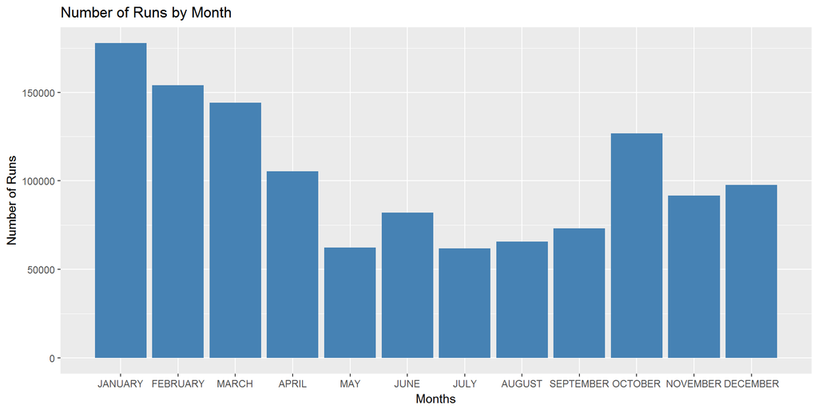

```r
runs_by_month <- odi_players %>% group_by(month) %>% summarise(total_runs = sum(Runs,na.rm=TRUE)) %>% arrange(-total_runs)
ggplot(runs_by_month,aes(month,total_runs)) + geom_bar(stat="identity",fill = "steelblue") +xlim(c("JANUARY","FEBRUARY","MARCH","APRIL","MAY","JUNE","JULY","AUGUST","SEPTEMBER","OCTOBER","NOVEMBER","DECEMBER")) + xlab("Months") + ylab("Number of Runs") + ggtitle("Number of Runs by Month")
```

The above barplot shows that most runs have been scored in the month of January gradually decreasing till March and then steeply falling for the month of may,slighting increasing in june and falling again in july,then gradually increasing till the end of the year while spiking at october.

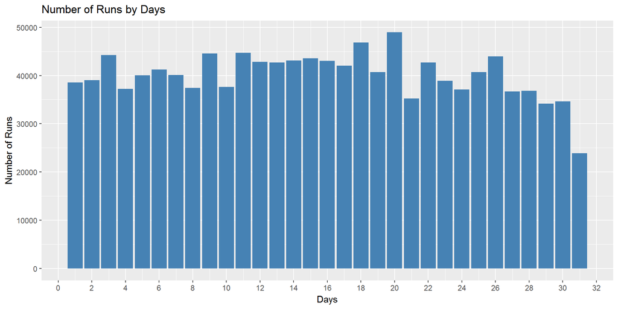

```r
runs_by_day <- odi_players %>% group_by(day) %>% summarise(total_runs = sum(Runs,na.rm=TRUE)) %>% arrange(-total_runs)
ggplot(runs_by_day,aes(day,total_runs)) + geom_bar(stat="identity",fill = "steelblue") + scale_x_continuous(breaks= scales::pretty_breaks(n=15)) + xlab("Days") + ylab("Number of Runs") + ggtitle("Number of Runs by Days")
```

The above barplot shows that most runs have been scored on the 20th of any month and least runs being scored on 31st of months which is justified since only 7 months have 31st.Also the runs scored in the end of the months is comparatively low.Rest of the days look to have fairly uniform runs scored

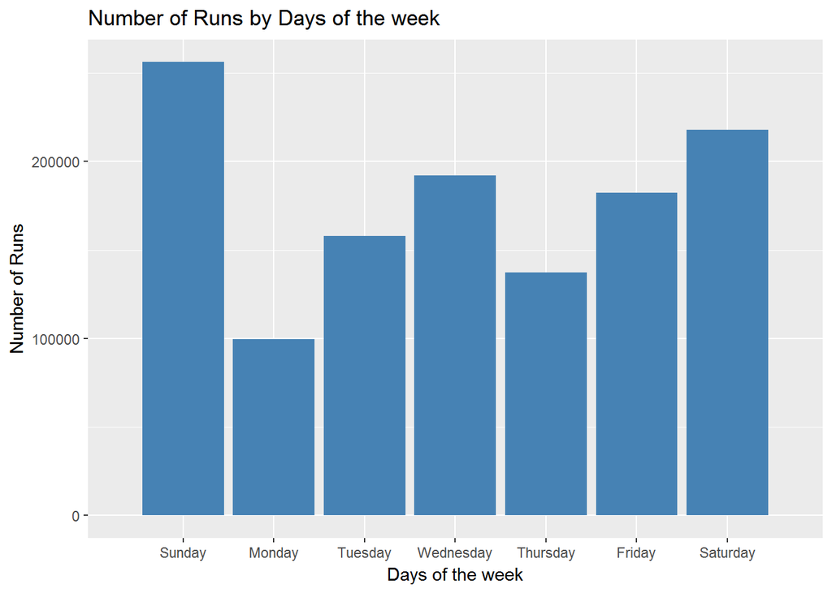

```r
runs_by_weekday <- odi_players %>% group_by(weekday) %>% summarise(total_runs = sum(Runs,na.rm=TRUE)) %>% arrange(-total_runs)
ggplot(runs_by_weekday,aes(weekday,total_runs)) + geom_bar(stat="identity",fill="steelblue") + xlim(c("Sunday","Monday","Tuesday","Wednesday","Thursday","Friday","Saturday")) + xlab("Days of the week") + ylab("Number of Runs") + ggtitle("Number of Runs by Days of the week")
```

The above barplot shows that most runs have been scored on Sundays followed by Saturdays which are weekends and more matches are thought to be scheduled on these days,while the least numbers of runs are scored on Mondays.

# 2. Create a new column by binning the Runs column using the following ranges and plot the frequency count of ranges.

*a. 0-25,* b. 26-50, *c. 51-75,* d. 76-100, *e. 100+

```r
odi_players$Run_bins<-cut(odi_players$Runs,c(-Inf,25,50,75,100,Inf),labels=c("0-25","26-50","51-75","75-100","100+"))
head(odi_players[,c("Runs","Run_bins")],25)
```

```
##    Runs Run_bins
## 1   118     100+
## 2   110     100+
## 3   100   75-100
## 4    82   75-100
## 5    57    51-75
## 6    55    51-75
## 7    37    26-50
## 8    34    26-50
## 9    20     0-25
## 10   16     0-25
## 11   11     0-25
## 12    8     0-25
## 13    2     0-25
## 14    1     0-25
## 15    1     0-25
## 16    0     0-25
## 17   62    51-75
## 18   60    51-75
## 19   58    51-75
## 20   58    51-75
## 21   47    26-50
## 22   47    26-50
## 23   23     0-25
## 24   23     0-25
## 25   15     0-25
```

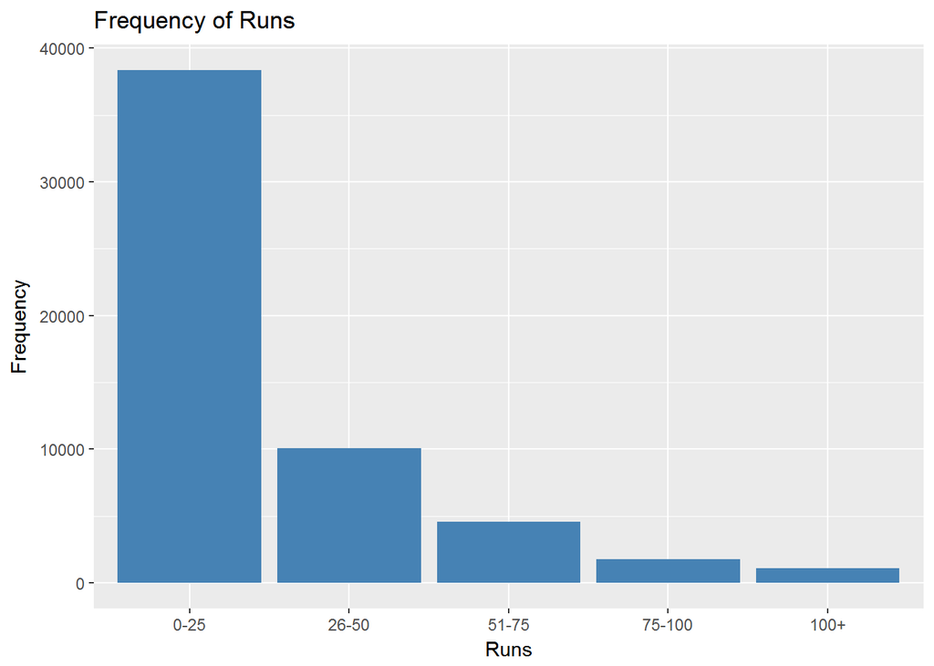

```r
bin_table<- as.data.frame(table(odi_players$Run_bins))
names(bin_table) <- c("RunBins","Frequency")
ggplot(bin_table,aes(RunBins,Frequency)) + geom_bar(stat="identity",fill="steelblue") + xlab("Runs") + ylab("Frequency") + ggtitle("Frequency of Runs")
```

The above barplot shows that by far,most runs scored are between 0-25 and the frequency of runs keep decreasing in the higher run buckets with the 100+ bucket having minimum frequency of Runs scored.

# 3. Consider the top ten players by total runs and compute and visualize the number of centuries across years and number of ducks across years.

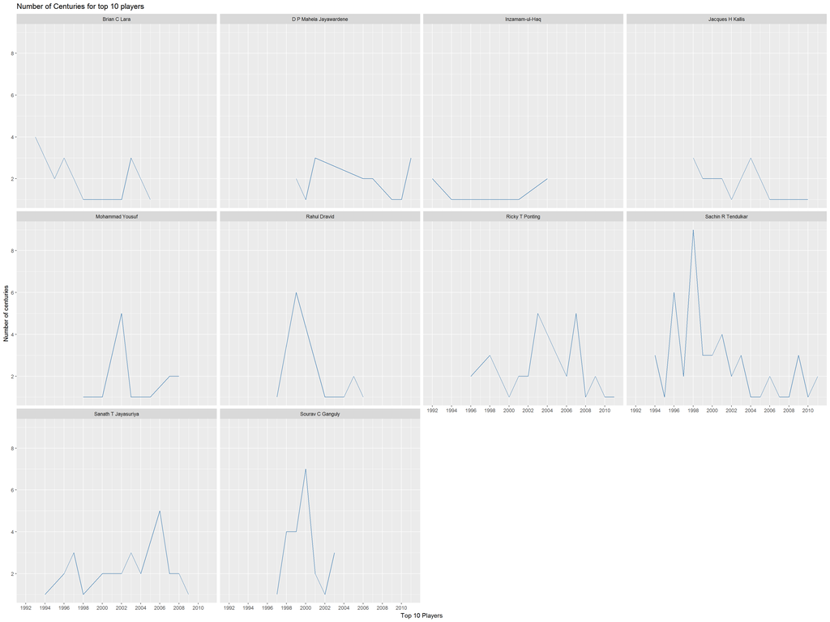

```r
player_10 <- odi_players %>% group_by(Player) %>% summarise("Total" = sum(Runs,na.rm=T)) %>% arrange(-Total)
player_10 <- head(player_10,10)
player_100 <- odi_players %>% filter(odi_players$Player %in% player_10$Player & odi_players$Runs>=100) %>% group_by(Player,year) %>% summarise(count= n())
ggplot(player_100,aes(year,count)) + geom_line(col = "steelblue") + ylab("Number of centuries") + xlab("Top 10 Players") + ggtitle("Number of Centuries for top 10 players")  + facet_wrap(~Player) + scale_y_continuous(breaks= scales::pretty_breaks(n=5)) + scale_x_continuous(breaks= scales::pretty_breaks(n=10))
```

The above line plot shows the number of centuries scored by top 10 players for different years of their careers.The highest number of centuries in a calendar year was scored in the year 1998 by Sachin Tendulkar(9 centuries).

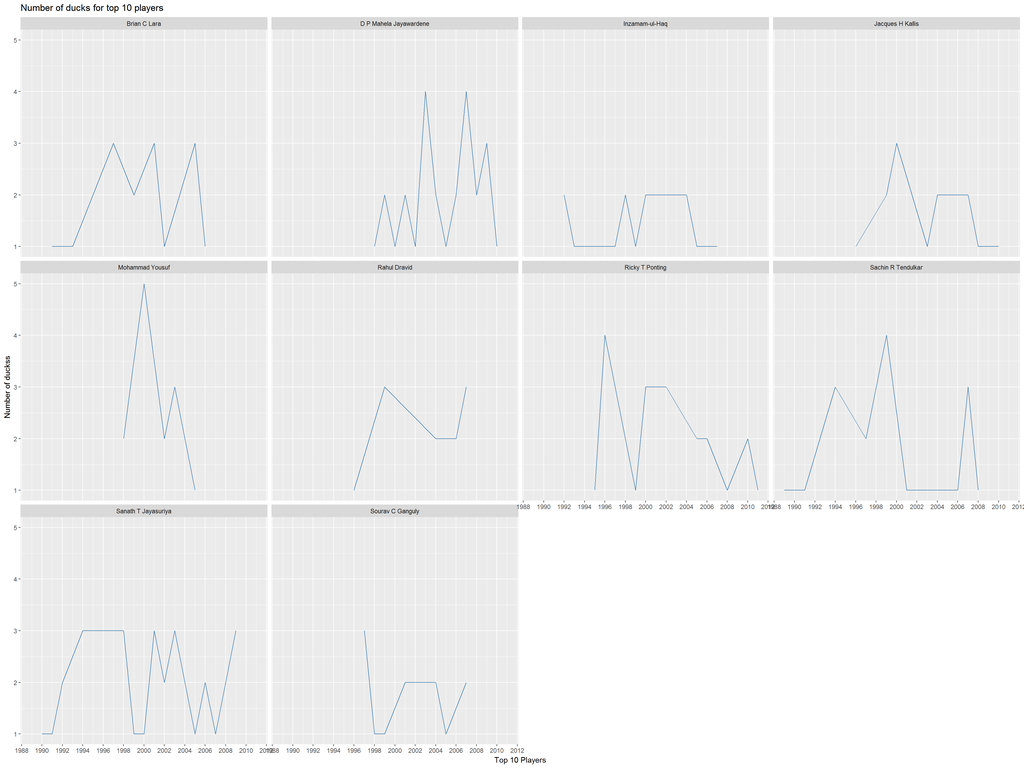

```r
player_0 <- odi_players %>% filter(odi_players$Player %in% player_10$Player & odi_players$Runs==0) %>% group_by(Player,year) %>% summarise(count = n())
ggplot(player_0,aes(year,count)) + geom_line(col = "steelblue") + ylab("Number of duckss") + xlab("Top 10 Players") + ggtitle("Number of ducks for top 10 players") + facet_wrap(~Player) + scale_x_continuous(breaks= scales::pretty_breaks(n=10))
```

# 4. Compute poor players by using following criteria.

## a. Calculate total number of runs by each player and then filter only for those players who have scored more than 5000 runs.

```r
player_poor1 <- odi_players %>% group_by(Player) %>% summarise("total_runs" = sum(Runs,na.rm=T)) %>% arrange(total_runs) %>% filter(total_runs>5000)
 player_poor1<-head(player_poor1,10)
 player_poor1
```

```
## # A tibble: 10 × 2
##                       Player total_runs
##                       <fctr>      <int>
## 1               Abdul Razzaq       5063
## 2             Andrew Symonds       5088
## 3         Paul D Collingwood       5092
## 4  Cuthbert Gordon Greenidge       5134
## 5          Roshan S Mahanama       5162
## 6      Alistair D R Campbell       5185
## 7               Shoaib Malik       5204
## 8            Damien R Martyn       5346
## 9        Alaysinhji D Jadeja       5359
## 10           Wessel J Cronje       5565
```

## b. Calculate total number of runs by each player and then filter only for those players who have played more than 50 matches.

```r
player_poor2 <- odi_players %>% group_by(Player) %>% summarise("total_runs" = sum(Runs,na.rm=T),matches= n()) %>% arrange(total_runs) %>% filter(matches>50)
player_poor2<- head(player_poor2,10)
player_poor2
```

```
## # A tibble: 10 × 3
##                     Player total_runs matches
##                     <fctr>      <int>   <int>
## 1          Glenn D McGrath        115      68
## 2         James M Anderson        199      63
## 3  Bapu K Venkatesh Prasad        221      63
## 4          Merwyn V Dillon        227      51
## 5   Conganige R D Fernando        239      57
## 6            Martin A Suji        247      52
## 7              Aaqib Javed        267      51
## 8           Daryl R Tuffey        295      52
## 9     Winston K M Benjamin        298      52
## 10        Courtney A Walsh        321      79
```

# 5. Create a new column by computing the number of words in each player’s name.

```r
odi_players$name_count <- sapply(str_split(odi_players$Player," "),length)
head(unique(odi_players[,c("Player","name_count")]),50)
```

```
##                   Player name_count
## 1       Mohammad Shahzad          2
## 17         Mohammad Nabi          2
## 33         Nawroz Mangal          2
## 50      Asghar Stanikzai          2
## 67       Noor Ali Zadran          3
## 80    Samiullah Shenwari          2
## 92          Karim Sadiq           3
## 107         Shabir Noori          2
## 115       Raees Ahmadzai          2
## 119       Mirwais Ashraf          2
## 126         Javed Ahmadi          2
## 131         Hamid Hassan          2
## 139           Khaliq Dad          2
## 143            Hasti Gul          2
```

[output cut: 36 more lines]

# 6. Cross-tabulation between month and day. Every row should have month and every column should have day of month. Value inside each cell should be the frequency count.

```r
xtabs(~odi_players$month+odi_players$day)
```

```
##                  odi_players$day
## odi_players$month   1   2   3   4   5   6   7   8   9  10  11  12  13  14  15  16  17  18  19  20
##                1  154 136 168 115 132  73 215 155 244 353 337 324 268 416 219 382 276 304 333 273
##                2  196 274 287 353 229 364 176 181 224 174 259 169 299 205 221 269 192 248 250 328
##                3  221 248 309 256 160 226 128 181 255 214 231 216 196 222 209 149 140 232 299 256
##                4  190 170 262 111 207 204 239 282 229 122 239 199 286 171 197 150 207 146 219  85
##                5   47  65  22  20  45  15  32  13  36  49  35  62  30  84  66  90  86 123 136 182
##                6   81  93  66  91  62 117 135 104 213  70 206  85 173 109 118 193 103 152 110 157
##                7  208  88 181 107 104 160 154  89 147 136 105 116  77  47  85 110  71 137  21 110
##                8   43  69  59  34  74 105  96  34  78  38  21  89  40 110  69 163  76 181  76 225
##                9   84 133  63 161 147 107 103  84  91  94  88 200 110 134 108 118 118 146  88 178
##                10 148 102 169  80 179  71 166  88 160 150 135 139 242 231 173 176 303 214 176 201
##                11 166 184 255 141 227 203 137 188 180 110 132 140  65 125 112  56  72 140  36  90
##                12 185 197 134 172 177 222 198 252 143 154 210 178 177 106 390 120 252 164 162 126
##                  odi_players$day
## odi_players$month  21  22  23  24  25  26  27  28  29  30  31
##                1  380 270 366 296 260 378 256 258 236 274 313
##                2  108 328 248 138 302 386 237 135 138   0   0
##                3  146 231 173 228 210 171 238 130 223 193 188
##                4   76  89  79  90  79  59  95  83  66  64   0
##                5  140 133 217 188 176 135 105 150  97 151  75
##                6  107  81 100 143  94 115 125 135 137  87   0
##                7   31  50  31  33  59  57  19  49  53  63  89
##                8  136 206  63 167 140 129 104 150 108 134 124
##                9   78 103  74  47  76 110  85  96 109 171   0
##                10 153 237 219  99 309 172 213 223 195 219 178
##                11  78 168 103 136  95 107 131 125 154 141   0
##                12 135  55 110  50  26 137  50  82  22  67 101
```

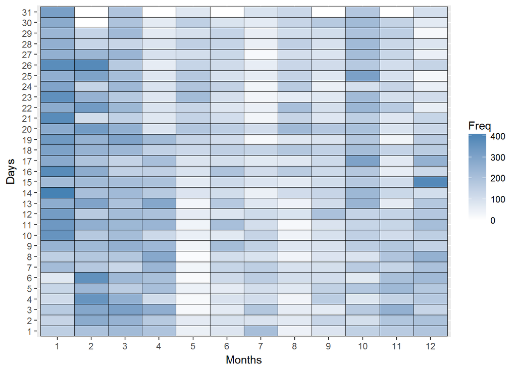

```r
crosstab<-as.data.frame(xtabs(~odi_players$month+odi_players$day))
names(crosstab)<- c("Months","Days","Freq")
ggplot(crosstab, aes(Months, Days)) + geom_tile(aes(fill = Freq), colour = "black") + scale_fill_gradient(low = "white",high = "steelblue")
```

The above heatmap shows the above cross tabulation frequencies of month and days,most matches seem to have been played in the month of January followed by February and March.Also it clearly shows that there have hardly been many matches from May to September while in the month of December there seem to have been alot of matches only on 15th.